# StatFest - satellite conference

September 2018

#### travel details

[figure not shown]

StatFest is a one day conference aimed at encouraging undergraduate students from historically underrepresented groups (African American, Hispanic, Native Americans) to consider careers and graduate studies in the statistical sciences. StatFest 2018 will be taking place on Saturday, September 22nd. Be sure to sign up today (see below)!

StatFest is an ongoing initiative of the American Statistical Association (ASA) through its Committee on Minorities in Statistics.

The conference includes:

- presentations from established professionals, academic leaders, and current graduate students that will help attendees understand the opportunities and routes for success in the field,
- opportunities for networking,
- opportunity for attendees to submit and present posters describing their research, and
- panel forums that will provide information and tips for a rewarding graduate student experience, achieving success as an academic statistician, opportunities in the private and government arenas, among other topics.

We are excited that StatFest 2018 will be held at [Amherst College](https://www.amherst.edu) (Amherst, Massachusetts), one of the premier liberal arts colleges in the nation, enrolling 1,800 talented, energetic and diverse young men and women. Amherst is one of the most diverse liberal arts colleges in the country. Our dedication to the centrality of inclusiveness helps us ensure that the college is a place to which all students feel they [belong](http://www.jkcf.org/amherst-college-gets-1-million-cooke-prize-for-admitting-supporting-and-graduating-outstanding-low-income-students).

For more information please contact [Nicholas Horton](https://www.amherst.edu/people/facstaff/nhorton), Renee’ Moore (renee.moore@emory.edu) or Jesse Chittams (chittams@nursing.upenn.edu).

## Registration

The conference is free but preregistration is **required** (deadline to register is Wednesday, September 19th). The registration link can be found [HERE](https://redcap.nursing.upenn.edu/surveys/?s=PJ4YFPXEFN).

Limited funds are available to partially defray travel costs (applicants are encouraged to register and make their requests as soon as possible: requests received by June 15th will be given first consideration). All travel reimbursements are subject to Amherst College guidelines and policies (see https://www.amherst.edu/offices/controller/accounts-payable/accounts-payable-policy/amherst-college-travel-policy for details).

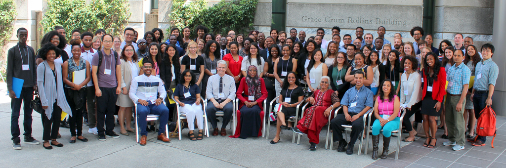

## Keynote speakers

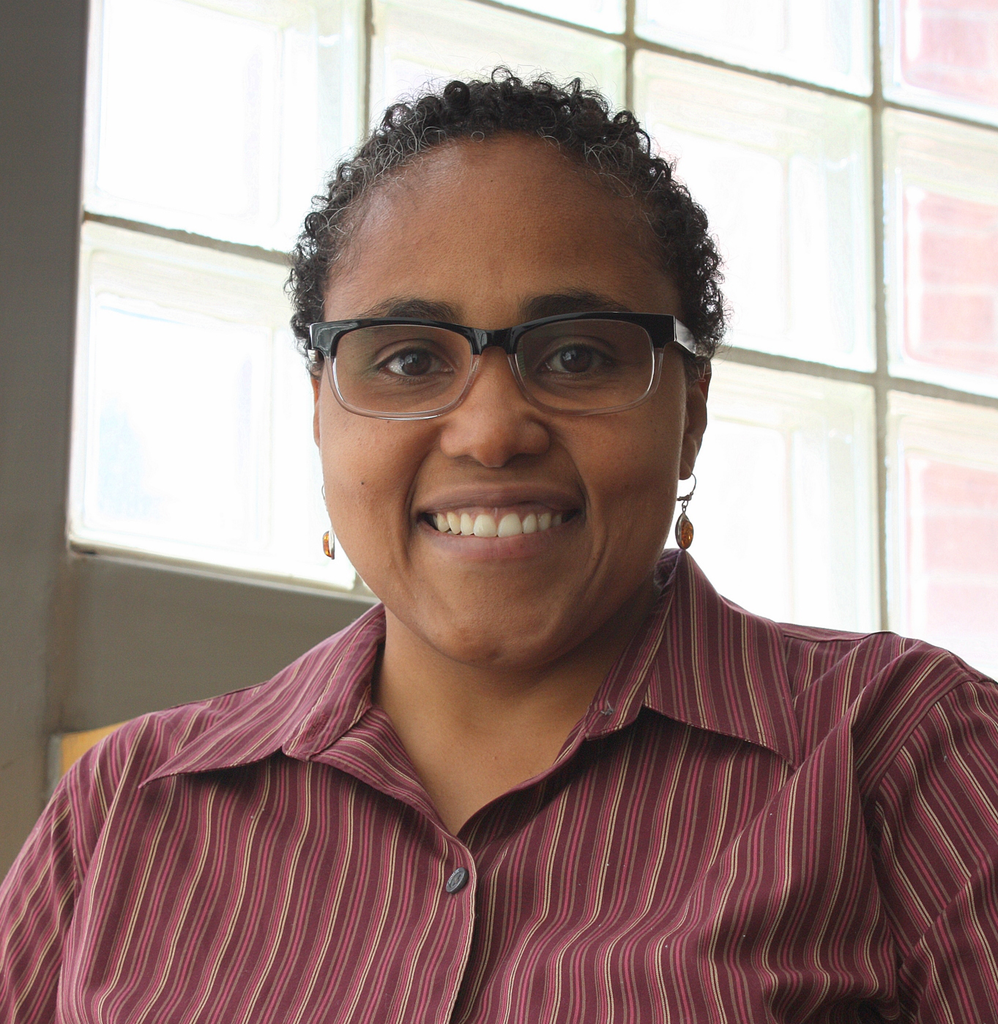

[Scarlett Bellamy](http://drexel.edu/dornsife/academics/faculty/Scarlett-Bellamy/) is the Past-President of [ENAR (Eastern North American Region)](https://www.enar.org/) of the International Biometrics Society and Professor of Biostatistics and director of the graduate program at the Department of Epidemiology and Biostatistics, Drexel University Dornsife School of Public Health.

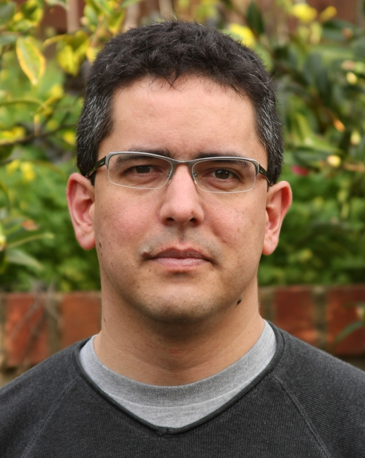

[Fernando Perez](https://bids.berkeley.edu/people/fernando-perez) created [iPython](https://ipython.org/) and co-created [Project Jupyter](http://jupyter.org/). He is a professor of statistics at the University of California/Berkeley and Senior Fellow of the Berkeley Institute for Data Science. Fernando and the Project Jupyter Team were honored with this year’s ACM Software System Award (https://twitter.com/UCBIDS/status/991731806100738048).

## Links

- StatFest 2018 Flyer 1 (students)
- StatFest 2018 Flyer 2 (students)
- StatFest 2018 Flyer 3 (keynotes)
- [Facebook group](https://www.facebook.com/groups/1683465345010041)
- [Earlier StatFest Conferences (Committee on Minorities in Statistics)](http://community.amstat.org/cmis/events/statfest)
- [Amstat News 2018](http://magazine.amstat.org/blog/2018/05/01/statfest18)
- [Amstat News 2017](http://magazine.amstat.org/blog/2017/08/01/statfest-2017)
- [Amherst College Office of Diversity and Inclusion](https://www.amherst.edu/amherst-story/diversity)
- [StatFest Twitter](https://twitter.com/statfest)

## Conduct policy

As an activity sponsored by the American Statistical Association (ASA), StatFest is committed to providing an atmosphere that encourages the free expression and exchange of ideas. Consistent with this commitment, it is the policy of the ASA that all participants in ASA activities, including StatFest, will find a welcoming and respectful environment free from unlawful discrimination, harassment, and retaliation. All aspects of StatFest are subject to the ASA’s [conduct policy](http://ww2.amstat.org/meetings/jsm/2018/conductpolicy.cfm).

Last updated August 6, 2018